# Dow Jones 30: Covariance Structure and Clustering

Eigen-analysis and k-means clustering of daily stock returns

Author

Kai Marsh

**NoteAbout this report**

This is an unsupervised look at the daily returns of the 30 Dow Jones Industrial Average constituents. It asks three questions: how much of the co-movement is driven by a single common factor, which stocks naturally group together, and whether trading days fall into distinct “regimes”. It was originally done as coursework for a university machine-learning course (RMIT, 2025) and has been consolidated here into a single reproducible report.

**TipKey findings**

- **One market factor dominates:** the first principal component explains 28.2% of daily return variance, more than three times the second (7.9%).
- **Technology stocks form their own cluster:** k-means separates HWP, INTC, IBM and MSFT. Their average pairwise correlation is 0.44, against 0.20 with the rest of the index, so holding several of them diversifies less than the ticker count suggests.
- **Trading days don’t fall into discrete regimes:** clustering days mainly splits market-up from market-down days (+0.89% vs −0.75% average return), with no clear elbow in within-cluster variance.

## Data

The data are daily returns for 30 Dow Jones constituents (2,527 trading days; tickers such as HWP, EK and SBC date the sample to the pre-2005 index). The analysis uses a 1,200-day window, days 1201–2400.

```r
dj <- read.csv("data/dj30_daily_returns.csv", check.names = FALSE)
dj[] <- lapply(dj, function(x) as.numeric(as.character(x)))
R <- as.matrix(dj[1201:2400, ])          # 1200 days x 30 stocks
stopifnot(!anyNA(R))
dim(R)
```

```
[1] 1200   30
```

## 1. Covariance structure: is there a market factor?

Treating stocks as variables, the $30 \times 30$ sample covariance matrix of returns is eigen-decomposed. If one eigenvalue dominates, a single common “market” factor drives most of the joint movement.

```r
S   <- cov(R)
ev  <- eigen(S, symmetric = TRUE)
lam <- ev$values
share <- lam / sum(lam)
data.frame(
  quantity = c("Covariance matrix", "Numerical rank", "Largest eigenvalue",
               "Smallest eigenvalue", "Share of variance, PC1", "Share, PC1-PC3"),
  value = c("30 x 30", sum(lam > max(lam) * 30 * .Machine$double.eps),
            signif(lam[1], 4), signif(lam[30], 4),
            sprintf("%.1f%%", 100 * share[1]), sprintf("%.1f%%", 100 * sum(share[1:3]))))
```

```
                quantity     value
1      Covariance matrix   30 x 30
2         Numerical rank        30
3     Largest eigenvalue   0.00398
4    Smallest eigenvalue 0.0001229
5 Share of variance, PC1     28.2%
6         Share, PC1-PC3     41.3%
```

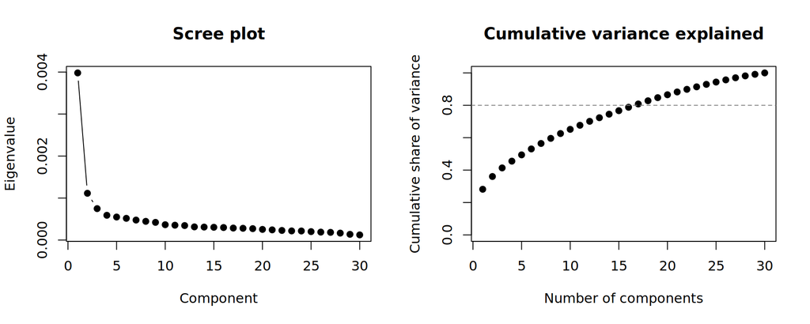

Figure 1: Scree plot of covariance eigenvalues (left) and cumulative share of return variance explained (right).

```r
par(mfrow = c(1, 2))
plot(lam, type = "b", pch = 19, xlab = "Component", ylab = "Eigenvalue", main = "Scree plot")
plot(cumsum(share), type = "b", pch = 19, ylim = c(0, 1), xlab = "Number of components",
     ylab = "Cumulative share of variance", main = "Cumulative variance explained")
abline(h = 0.8, lty = 2, col = "grey50")
```

$$\mathbf S = \frac{1}{T-1}\sum_{t=1}^{T}(\mathbf r_t - \bar{\mathbf r})(\mathbf r_t - \bar{\mathbf r})' = \mathbf V\boldsymbol\Lambda\mathbf V', \qquad \text{cumulative share}_k = \frac{\sum_{j=1}^{k}\lambda_j}{\sum_{j=1}^{30}\lambda_j}$$

$\mathbf r_t$ vector of the 30 stocks’ returns on day $t$ · $T$ = 1,200 days · $\mathbf S$ sample covariance matrix · $\lambda_j$ $j$-th eigenvalue (left panel), the return variance carried by component $j$ · right panel plots the cumulative share against $k$, with 80% dashed.

The covariance matrix has full rank (30), so no stock’s return is an exact combination of the others. The first component explains 28.2% of total return variance, far more than any other component (Figure 1). This is the familiar **market factor**: most of the time, Dow stocks rise and fall together. The remaining variance is spread over many small components, which reflect sector and stock-specific moves.

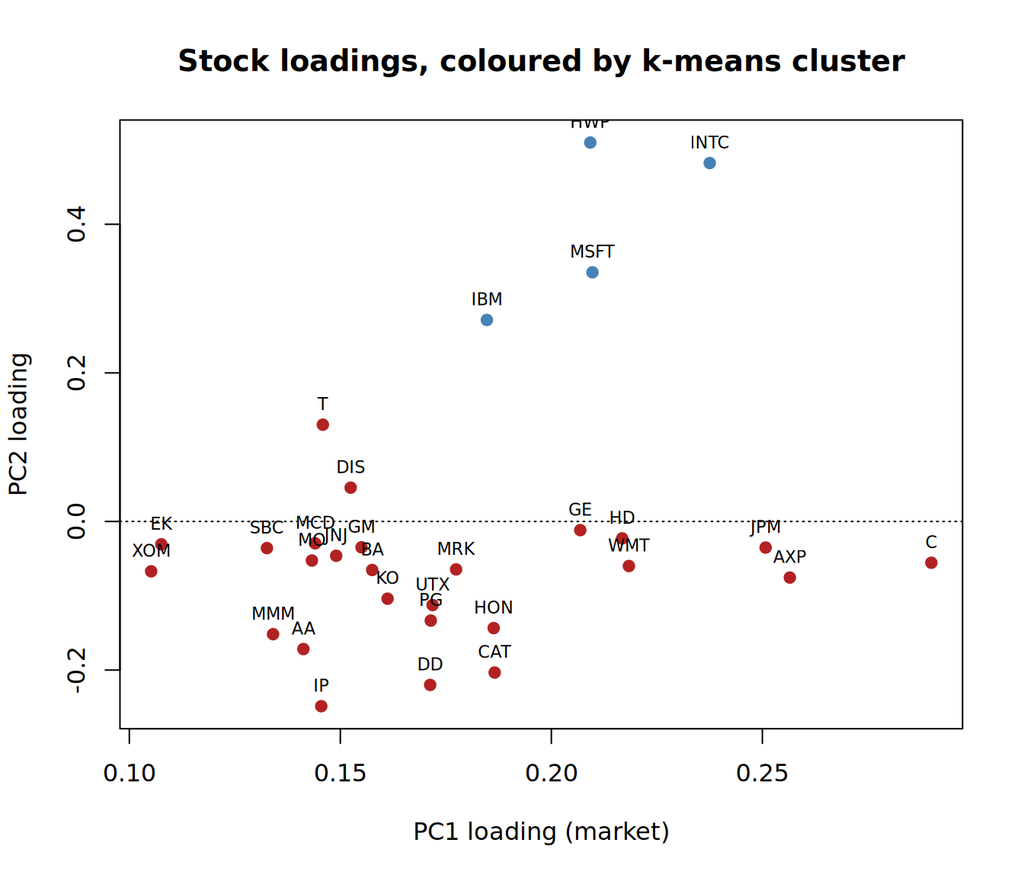

Figure 2: Stock loadings on the first two principal components. PC1 loadings share a sign (the market factor); PC2 separates a group of technology stocks from the rest.

```r
L <- ev$vectors[, 1:2]; if (mean(L[, 1]) < 0) L[, 1] <- -L[, 1]
rownames(L) <- colnames(R)
set.seed(2025)
km_s <- kmeans(t(R), centers = 2, nstart = 25, iter.max = 50)
plot(L, pch = 19, col = c("steelblue", "firebrick")[km_s$cluster],
     xlab = "PC1 loading (market)", ylab = "PC2 loading", main = "Stock loadings, coloured by k-means cluster")
text(L, labels = rownames(L), pos = 3, cex = 0.7)
abline(h = 0, lty = 3)
```

$$\text{PC}_{j,t} = \mathbf v_j'(\mathbf r_t - \bar{\mathbf r}), \qquad \min_{C_1, C_2}\; \sum_{c=1}^{2}\sum_{i \in C_c} \lVert \mathbf x_i - \boldsymbol\mu_c \rVert^2$$

$\mathbf v_j$ eigenvector $j$ of $\mathbf S$; its entries are the stocks’ loadings (axes) · $\mathbf x_i \in \mathbb R^{1200}$ stock $i$’s series of daily returns · $C_c$ k-means cluster $c$ (colours) · $\boldsymbol\mu_c$ its centroid.

## 2. Which stocks move together?

Each stock is treated as an observation, described by its 1,200 daily returns, and grouped with k-means ($k = 2$, 25 random starts).

```r
small <- which.min(km_s$size)
km_s$size
```

```
[1]  4 26
```

```r
colnames(R)[km_s$cluster == small]
```

```
[1] "HWP"  "INTC" "IBM"  "MSFT"
```

k-means splits off a small group of **4 stocks (HWP, INTC, IBM, MSFT)** from the other 26. These are the technology names in the index. They include the most volatile stocks in the index (HWP and INTC have the highest daily standard deviations). Their average pairwise correlation is about 0.44, against about 0.20 with the other 26 stocks, which is consistent with their separation on PC2 in Figure 2. For portfolio construction, this means that holding several of these names adds less diversification than the ticker count suggests.

## 3. Do trading days form regimes?

Next, each **day** is treated as an observation, described by its vector of 30 stock returns, and clustered for $k = 2, \ldots, 9$. Two quantities are tracked: the total within-cluster sum of squares $W$ and the between-cluster sum of squares $B$.

```r
K <- 2:9
set.seed(2025)
fits <- lapply(K, function(k) kmeans(R, centers = k, nstart = 25, iter.max = 50))
WB <- data.frame(k = K,
                 W = sapply(fits, `[[`, "tot.withinss"),
                 B = sapply(fits, `[[`, "betweenss"))
WB$W_drop_pct <- c(NA, round(-100 * diff(WB$W) / head(WB$W, -1), 1))
WB$sizes <- sapply(fits, function(f) paste(sort(f$size, decreasing = TRUE), collapse = "/"))
WB$W <- signif(WB$W, 4); WB$B <- signif(WB$B, 4)
WB
```

```
  k     W     B W_drop_pct                            sizes
1 2 14.32 2.618         NA                          602/598
2 3 13.44 3.504        6.2                      643/362/195
3 4 12.96 3.979        3.5                  394/345/285/176
4 5 12.61 4.330        2.7              354/311/247/171/117
5 6 12.36 4.579        2.0          279/251/247/220/102/101
6 7 12.13 4.814        1.9        277/253/247/194/123/102/4
7 8 11.94 4.997        1.5     252/241/232/146/122/121/82/4
8 9 11.78 5.164        1.4 243/199/199/156/154/123/111/11/4
```

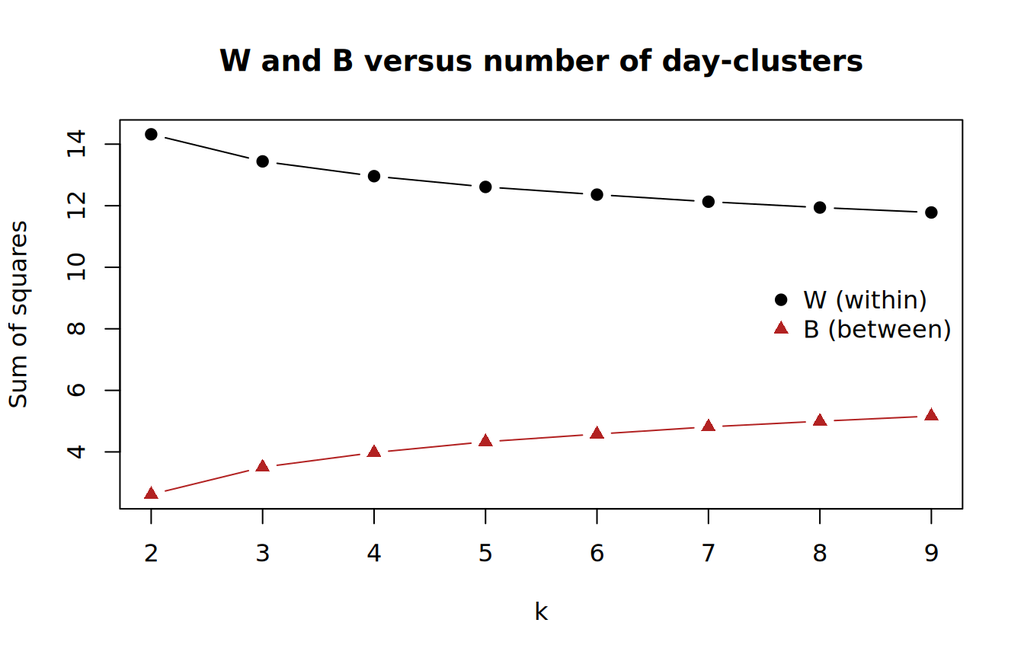

Figure 3: Within-cluster (W) and between-cluster (B) sums of squares against the number of day-clusters k. W + B equals the (constant) total sum of squares.

```r
matplot(WB$k, cbind(WB$W, WB$B), type = "b", pch = c(19, 17), lty = 1,
        col = c("black", "firebrick"), xlab = "k", ylab = "Sum of squares",
        main = "W and B versus number of day-clusters")
legend("right", c("W (within)", "B (between)"), pch = c(19, 17), col = c("black", "firebrick"), bty = "n")
```

$$\underbrace{\sum_{t}\lVert\mathbf r_t - \bar{\mathbf r}\rVert^2}_{\text{total (fixed)}} = \underbrace{\sum_{c=1}^{k}\sum_{t \in C_c}\lVert\mathbf r_t - \boldsymbol\mu_c\rVert^2}_{W} + \underbrace{\sum_{c=1}^{k} n_c\,\lVert\boldsymbol\mu_c - \bar{\mathbf r}\rVert^2}_{B}$$

$\mathbf r_t$ day $t$’s vector of 30 returns · $C_c$ the days in cluster $c$ · $n_c$ their number · $\boldsymbol\mu_c$ cluster centroid · $\bar{\mathbf r}$ overall mean. k-means minimises $W$, so as $k$ rises $W$ falls and $B$ rises by the same amount.

$W$ falls and $B$ rises as $k$ grows, as they must, since $W + B$ is fixed (Figure 3). There is no clear elbow: each extra cluster removes only a modest share of $W$ (the `W_drop_pct` column), and the gains shrink steadily.

## Limitations

- k-means assumes roughly spherical, equal-variance clusters and uses Euclidean distance on raw returns, so high-volatility stocks and days have more influence. Clustering on correlations, or on standardised returns, is a natural sensitivity check.
- The 1,200-day window is a single historical period. Cluster membership (especially the technology group) may not be stable in other periods.